# Risk Factor Analysis

## Outcome Variable

**Outcome Variable:** stunted

## Predictor Variables

**Intervention Variable:** anywast06

**Adjustment Set:**

unadjusted

## Stratifying Variables

The analysis was stratified on these variable(s):

- agecat
- studyid
- country

## Data Summary

| agecat | studyid | country | anywast06 | stunted | n_cell | n |
| --- | --- | --- | --- | --- | --- | --- |
| Birth | CMC-V-BCS-2002 | INDIA | 0 | 0 | 30 | 92 |
| Birth | CMC-V-BCS-2002 | INDIA | 0 | 1 | 7 | 92 |
| Birth | CMC-V-BCS-2002 | INDIA | 1 | 0 | 45 | 92 |
| Birth | CMC-V-BCS-2002 | INDIA | 1 | 1 | 10 | 92 |
| Birth | CMIN | BANGLADESH | 0 | 0 | 13 | 20 |
| Birth | CMIN | BANGLADESH | 0 | 1 | 2 | 20 |
| Birth | CMIN | BANGLADESH | 1 | 0 | 4 | 20 |
| Birth | CMIN | BANGLADESH | 1 | 1 | 1 | 20 |
| Birth | CONTENT | PERU | 0 | 0 | 2 | 2 |
| Birth | CONTENT | PERU | 0 | 1 | 0 | 2 |
| Birth | CONTENT | PERU | 1 | 0 | 0 | 2 |
| Birth | CONTENT | PERU | 1 | 1 | 0 | 2 |
| Birth | EE | PAKISTAN | 0 | 0 | 86 | 240 |
| Birth | EE | PAKISTAN | 0 | 1 | 70 | 240 |
| Birth | EE | PAKISTAN | 1 | 0 | 54 | 240 |
| Birth | EE | PAKISTAN | 1 | 1 | 30 | 240 |
| Birth | GMS-Nepal | NEPAL | 0 | 0 | 340 | 684 |
| Birth | GMS-Nepal | NEPAL | 0 | 1 | 82 | 684 |
| Birth | GMS-Nepal | NEPAL | 1 | 0 | 234 | 684 |
| Birth | GMS-Nepal | NEPAL | 1 | 1 | 28 | 684 |
| Birth | IRC | INDIA | 0 | 0 | 137 | 388 |
| Birth | IRC | INDIA | 0 | 1 | 27 | 388 |
| Birth | IRC | INDIA | 1 | 0 | 206 | 388 |
| Birth | IRC | INDIA | 1 | 1 | 18 | 388 |
| Birth | Keneba | GAMBIA | 0 | 0 | 934 | 1542 |
| Birth | Keneba | GAMBIA | 0 | 1 | 60 | 1542 |
| Birth | Keneba | GAMBIA | 1 | 0 | 526 | 1542 |
| Birth | Keneba | GAMBIA | 1 | 1 | 22 | 1542 |
| Birth | MAL-ED | BANGLADESH | 0 | 0 | 146 | 229 |
| Birth | MAL-ED | BANGLADESH | 0 | 1 | 31 | 229 |

[output cut: 170 more lines]

The following strata were considered:

- agecat: 24 months, studyid: CMC-V-BCS-2002, country: INDIA
- agecat: 24 months, studyid: CMIN, country: BANGLADESH
- agecat: 24 months, studyid: CONTENT, country: PERU
- agecat: 24 months, studyid: EE, country: PAKISTAN
- agecat: 24 months, studyid: GMS-Nepal, country: NEPAL
- agecat: 24 months, studyid: IRC, country: INDIA
- agecat: 24 months, studyid: Keneba, country: GAMBIA
- agecat: 24 months, studyid: MAL-ED, country: BANGLADESH
- agecat: 24 months, studyid: MAL-ED, country: BRAZIL
- agecat: 24 months, studyid: MAL-ED, country: INDIA
- agecat: 24 months, studyid: MAL-ED, country: NEPAL
- agecat: 24 months, studyid: MAL-ED, country: PERU
- agecat: 24 months, studyid: MAL-ED, country: SOUTH AFRICA
- agecat: 24 months, studyid: MAL-ED, country: TANZANIA, UNITED REPUBLIC OF
- agecat: 24 months, studyid: PROVIDE, country: BANGLADESH
- agecat: 24 months, studyid: TanzaniaChild2, country: TANZANIA, UNITED REPUBLIC OF
- agecat: 6 months, studyid: CMC-V-BCS-2002, country: INDIA
- agecat: 6 months, studyid: CMIN, country: BANGLADESH
- agecat: 6 months, studyid: CONTENT, country: PERU
- agecat: 6 months, studyid: EE, country: PAKISTAN
- agecat: 6 months, studyid: GMS-Nepal, country: NEPAL
- agecat: 6 months, studyid: Guatemala BSC, country: GUATEMALA
- agecat: 6 months, studyid: IRC, country: INDIA
- agecat: 6 months, studyid: Keneba, country: GAMBIA
- agecat: 6 months, studyid: MAL-ED, country: BANGLADESH
- agecat: 6 months, studyid: MAL-ED, country: BRAZIL
- agecat: 6 months, studyid: MAL-ED, country: INDIA
- agecat: 6 months, studyid: MAL-ED, country: NEPAL
- agecat: 6 months, studyid: MAL-ED, country: PERU
- agecat: 6 months, studyid: MAL-ED, country: SOUTH AFRICA
- agecat: 6 months, studyid: MAL-ED, country: TANZANIA, UNITED REPUBLIC OF
- agecat: 6 months, studyid: PROVIDE, country: BANGLADESH
- agecat: 6 months, studyid: ResPak, country: PAKISTAN
- agecat: 6 months, studyid: TanzaniaChild2, country: TANZANIA, UNITED REPUBLIC OF
- agecat: Birth, studyid: CMC-V-BCS-2002, country: INDIA
- agecat: Birth, studyid: CMIN, country: BANGLADESH
- agecat: Birth, studyid: CONTENT, country: PERU
- agecat: Birth, studyid: EE, country: PAKISTAN
- agecat: Birth, studyid: GMS-Nepal, country: NEPAL
- agecat: Birth, studyid: IRC, country: INDIA
- agecat: Birth, studyid: Keneba, country: GAMBIA
- agecat: Birth, studyid: MAL-ED, country: BANGLADESH
- agecat: Birth, studyid: MAL-ED, country: BRAZIL
- agecat: Birth, studyid: MAL-ED, country: INDIA
- agecat: Birth, studyid: MAL-ED, country: NEPAL
- agecat: Birth, studyid: MAL-ED, country: PERU
- agecat: Birth, studyid: MAL-ED, country: SOUTH AFRICA
- agecat: Birth, studyid: MAL-ED, country: TANZANIA, UNITED REPUBLIC OF
- agecat: Birth, studyid: PROVIDE, country: BANGLADESH
- agecat: Birth, studyid: ResPak, country: PAKISTAN

### Dropped Strata

Some strata were dropped due to rare outcomes:

- agecat: Birth, studyid: CMIN, country: BANGLADESH
- agecat: Birth, studyid: CONTENT, country: PERU
- agecat: Birth, studyid: MAL-ED, country: BRAZIL
- agecat: Birth, studyid: MAL-ED, country: INDIA
- agecat: Birth, studyid: MAL-ED, country: NEPAL
- agecat: Birth, studyid: MAL-ED, country: PERU
- agecat: Birth, studyid: MAL-ED, country: SOUTH AFRICA
- agecat: Birth, studyid: MAL-ED, country: TANZANIA, UNITED REPUBLIC OF
- agecat: Birth, studyid: ResPak, country: PAKISTAN
- agecat: 6 months, studyid: CONTENT, country: PERU
- agecat: 6 months, studyid: Guatemala BSC, country: GUATEMALA
- agecat: 6 months, studyid: MAL-ED, country: BRAZIL
- agecat: 6 months, studyid: MAL-ED, country: PERU
- agecat: 6 months, studyid: MAL-ED, country: TANZANIA, UNITED REPUBLIC OF
- agecat: 24 months, studyid: CONTENT, country: PERU
- agecat: 24 months, studyid: MAL-ED, country: BRAZIL
- agecat: 24 months, studyid: MAL-ED, country: PERU
- agecat: 24 months, studyid: MAL-ED, country: TANZANIA, UNITED REPUBLIC OF
- agecat: 24 months, studyid: TanzaniaChild2, country: TANZANIA, UNITED REPUBLIC OF

## Methods Detail

We’re interested in the causal parameters $E[Y_a]$ for all values of $a \in \mathcal{A}$. These parameters represent the mean outcome if, possibly contrary to fact, we intervened to set all units to have $A=a$. Under the randomization and positivity assumptions, these are identified by the statistical parameters $\psi_a=E_W[E_{Y|A,W}(Y|A=a,W)]$. In addition, we’re interested in the mean of $Y$, $E[Y]$ under no intervention (the observed mean). We will estimate these parameters by using SuperLearner to fit the relevant likelihood factors – $E_{Y|A,W}(Y|A=a,W)$ and $p(A=a|W)$, and then updating our likelihood fit using a joint TMLE.

For unadjusted analyses ($W=\{\}$), initial likelihoods were estimated using Lrnr_glm to estimate the simple $E(Y|A)$ and Lrnr_mean to estimate $p(A)$. For adjusted analyses, a small library containing Lrnr_glmnet, Lrnr_xgboost, and Lrnr_mean was used.

Having estimated these parameters, we will then use the delta method to estimate relative risks and attributable risks relative to a prespecified baseline level of $A$.

# Results Detail

## Results Plots

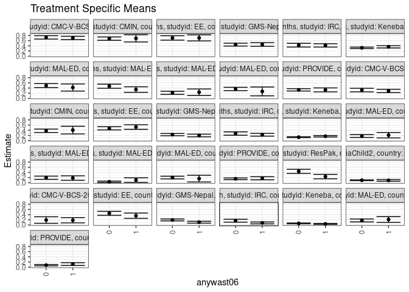

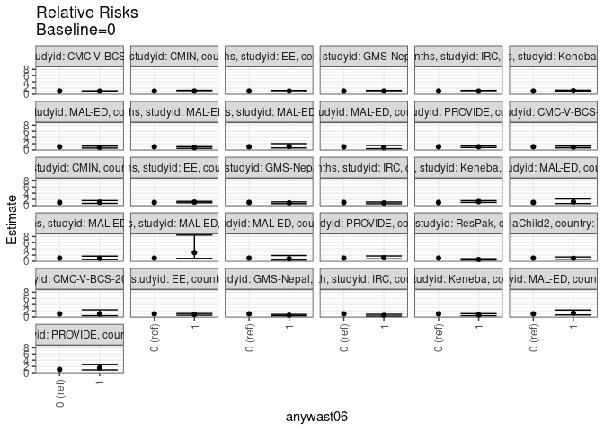

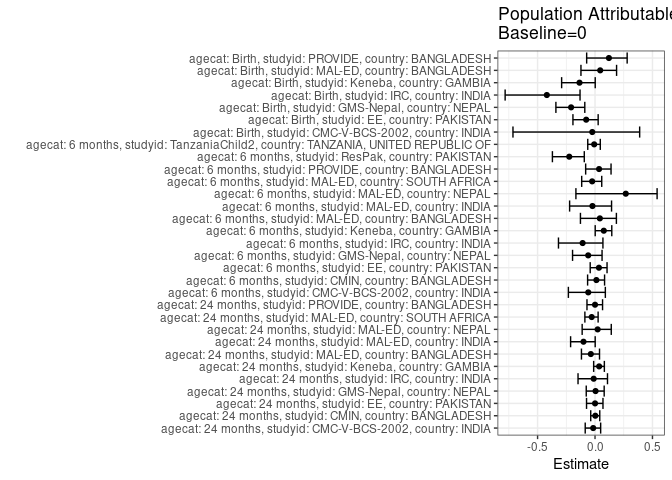

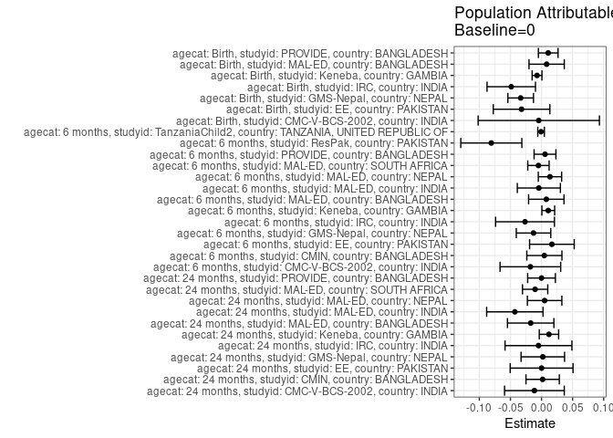

## Results Table

### Parameter: TSM

| agecat | studyid | country | intervention_level | baseline_level | estimate | ci_lower | ci_upper |
| --- | --- | --- | --- | --- | --- | --- | --- |
| Birth | CMC-V-BCS-2002 | INDIA | 0 | NA | 0.1891892 | 0.0622989 | 0.3160795 |
| Birth | CMC-V-BCS-2002 | INDIA | 1 | NA | 0.1818182 | 0.0793277 | 0.2843087 |
| Birth | EE | PAKISTAN | 0 | NA | 0.4487179 | 0.3705073 | 0.5269286 |
| Birth | EE | PAKISTAN | 1 | NA | 0.3571429 | 0.2544611 | 0.4598246 |
| Birth | GMS-Nepal | NEPAL | 0 | NA | 0.1943128 | 0.1565344 | 0.2320912 |
| Birth | GMS-Nepal | NEPAL | 1 | NA | 0.1068702 | 0.0694332 | 0.1443072 |
| Birth | IRC | INDIA | 0 | NA | 0.1646341 | 0.1078032 | 0.2214651 |
| Birth | IRC | INDIA | 1 | NA | 0.0803571 | 0.0447115 | 0.1160028 |
| Birth | Keneba | GAMBIA | 0 | NA | 0.0603622 | 0.0455521 | 0.0751723 |
| Birth | Keneba | GAMBIA | 1 | NA | 0.0401460 | 0.0237052 | 0.0565868 |
| Birth | MAL-ED | BANGLADESH | 0 | NA | 0.1751412 | 0.1190241 | 0.2312584 |
| Birth | MAL-ED | BANGLADESH | 1 | NA | 0.2115385 | 0.1002932 | 0.3227838 |
| Birth | PROVIDE | BANGLADESH | 0 | NA | 0.0782828 | 0.0518017 | 0.1047639 |
| Birth | PROVIDE | BANGLADESH | 1 | NA | 0.1188811 | 0.0657857 | 0.1719765 |
| 6 months | CMC-V-BCS-2002 | INDIA | 0 | NA | 0.3220339 | 0.2531033 | 0.3909645 |
| 6 months | CMC-V-BCS-2002 | INDIA | 1 | NA | 0.2872340 | 0.2224667 | 0.3520014 |
| 6 months | CMIN | BANGLADESH | 0 | NA | 0.3781095 | 0.3109339 | 0.4452850 |
| 6 months | CMIN | BANGLADESH | 1 | NA | 0.4047619 | 0.2560095 | 0.5535143 |
| 6 months | EE | PAKISTAN | 0 | NA | 0.4738956 | 0.4117931 | 0.5359980 |
| 6 months | EE | PAKISTAN | 1 | NA | 0.5241935 | 0.4361736 | 0.6122135 |
| 6 months | GMS-Nepal | NEPAL | 0 | NA | 0.2291667 | 0.1841866 | 0.2741467 |
| 6 months | GMS-Nepal | NEPAL | 1 | NA | 0.1973684 | 0.1456598 | 0.2490770 |
| 6 months | IRC | INDIA | 0 | NA | 0.2722222 | 0.2071183 | 0.3373262 |
| 6 months | IRC | INDIA | 1 | NA | 0.2246696 | 0.1703089 | 0.2790303 |
| 6 months | Keneba | GAMBIA | 0 | NA | 0.1311589 | 0.1137252 | 0.1485927 |
| 6 months | Keneba | GAMBIA | 1 | NA | 0.1674797 | 0.1379611 | 0.1969982 |
| 6 months | MAL-ED | BANGLADESH | 0 | NA | 0.1748634 | 0.1197144 | 0.2300124 |
| 6 months | MAL-ED | BANGLADESH | 1 | NA | 0.2068966 | 0.1024297 | 0.3113634 |
| 6 months | MAL-ED | INDIA | 0 | NA | 0.1949686 | 0.1332579 | 0.2566792 |
| 6 months | MAL-ED | INDIA | 1 | NA | 0.1818182 | 0.0954869 | 0.2681495 |
| 6 months | MAL-ED | NEPAL | 0 | NA | 0.0372340 | 0.0101120 | 0.0643560 |
| 6 months | MAL-ED | NEPAL | 1 | NA | 0.1041667 | 0.0175647 | 0.1907686 |
| 6 months | MAL-ED | SOUTH AFRICA | 0 | NA | 0.2017937 | 0.1490144 | 0.2545730 |
| 6 months | MAL-ED | SOUTH AFRICA | 1 | NA | 0.1612903 | 0.0315623 | 0.2910184 |
| 6 months | PROVIDE | BANGLADESH | 0 | NA | 0.1533333 | 0.1200155 | 0.1866511 |
| 6 months | PROVIDE | BANGLADESH | 1 | NA | 0.1753247 | 0.1152197 | 0.2354297 |
| 6 months | ResPak | PAKISTAN | 0 | NA | 0.4405594 | 0.3590196 | 0.5220993 |
| 6 months | ResPak | PAKISTAN | 1 | NA | 0.2395833 | 0.1540221 | 0.3251446 |
| 6 months | TanzaniaChild2 | TANZANIA, UNITED REPUBLIC OF | 0 | NA | 0.0978009 | 0.0837920 | 0.1118099 |
| 6 months | TanzaniaChild2 | TANZANIA, UNITED REPUBLIC OF | 1 | NA | 0.0930233 | 0.0602012 | 0.1258453 |
| 24 months | CMC-V-BCS-2002 | INDIA | 0 | NA | 0.7272727 | 0.6613859 | 0.7931596 |
| 24 months | CMC-V-BCS-2002 | INDIA | 1 | NA | 0.7052632 | 0.6403462 | 0.7701801 |
| 24 months | CMIN | BANGLADESH | 0 | NA | 0.6800000 | 0.6152169 | 0.7447831 |
| 24 months | CMIN | BANGLADESH | 1 | NA | 0.6904762 | 0.5503743 | 0.8305781 |
| 24 months | EE | PAKISTAN | 0 | NA | 0.7064220 | 0.6206723 | 0.7921718 |
| 24 months | EE | PAKISTAN | 1 | NA | 0.7068966 | 0.5893996 | 0.8243935 |
| 24 months | GMS-Nepal | NEPAL | 0 | NA | 0.4466667 | 0.3903524 | 0.5029809 |
| 24 months | GMS-Nepal | NEPAL | 1 | NA | 0.4521277 | 0.3809105 | 0.5233448 |
| 24 months | IRC | INDIA | 0 | NA | 0.4254144 | 0.3532997 | 0.4975291 |
| 24 months | IRC | INDIA | 1 | NA | 0.4166667 | 0.3525951 | 0.4807382 |
| 24 months | Keneba | GAMBIA | 0 | NA | 0.3226398 | 0.2948910 | 0.3503885 |
| 24 months | Keneba | GAMBIA | 1 | NA | 0.3622881 | 0.3189115 | 0.4056647 |
| 24 months | MAL-ED | BANGLADESH | 0 | NA | 0.4938272 | 0.4166561 | 0.5709982 |
| 24 months | MAL-ED | BANGLADESH | 1 | NA | 0.4200000 | 0.2828713 | 0.5571287 |
| 24 months | MAL-ED | INDIA | 0 | NA | 0.4701987 | 0.3904147 | 0.5499826 |
| 24 months | MAL-ED | INDIA | 1 | NA | 0.3421053 | 0.2352101 | 0.4490004 |
| 24 months | MAL-ED | NEPAL | 0 | NA | 0.2142857 | 0.1545415 | 0.2740299 |
| 24 months | MAL-ED | NEPAL | 1 | NA | 0.2391304 | 0.1155937 | 0.3626672 |
| 24 months | MAL-ED | SOUTH AFRICA | 0 | NA | 0.3632075 | 0.2983335 | 0.4280816 |
| 24 months | MAL-ED | SOUTH AFRICA | 1 | NA | 0.2692308 | 0.0983756 | 0.4400860 |
| 24 months | PROVIDE | BANGLADESH | 0 | NA | 0.3287037 | 0.2843692 | 0.3730382 |
| 24 months | PROVIDE | BANGLADESH | 1 | NA | 0.3287671 | 0.2525016 | 0.4050327 |

### Parameter: E(Y)

| agecat | studyid | country | intervention_level | baseline_level | estimate | ci_lower | ci_upper |
| --- | --- | --- | --- | --- | --- | --- | --- |
| Birth | CMC-V-BCS-2002 | INDIA | NA | NA | 0.1847826 | 0.1050392 | 0.2645260 |
| Birth | EE | PAKISTAN | NA | NA | 0.4166667 | 0.3541635 | 0.4791698 |
| Birth | GMS-Nepal | NEPAL | NA | NA | 0.1608187 | 0.1332679 | 0.1883695 |
| Birth | IRC | INDIA | NA | NA | 0.1159794 | 0.0840777 | 0.1478811 |
| Birth | Keneba | GAMBIA | NA | NA | 0.0531777 | 0.0419744 | 0.0643810 |
| Birth | MAL-ED | BANGLADESH | NA | NA | 0.1834061 | 0.1331729 | 0.2336393 |
| Birth | PROVIDE | BANGLADESH | NA | NA | 0.0890538 | 0.0649864 | 0.1131212 |
| 6 months | CMC-V-BCS-2002 | INDIA | NA | NA | 0.3041096 | 0.2568508 | 0.3513684 |
| 6 months | CMIN | BANGLADESH | NA | NA | 0.3827160 | 0.3214780 | 0.4439541 |
| 6 months | EE | PAKISTAN | NA | NA | 0.4906166 | 0.4398159 | 0.5414174 |
| 6 months | GMS-Nepal | NEPAL | NA | NA | 0.2163121 | 0.1823021 | 0.2503220 |
| 6 months | IRC | INDIA | NA | NA | 0.2457002 | 0.2038248 | 0.2875757 |
| 6 months | Keneba | GAMBIA | NA | NA | 0.1420233 | 0.1269309 | 0.1571158 |
| 6 months | MAL-ED | BANGLADESH | NA | NA | 0.1825726 | 0.1336978 | 0.2314474 |
| 6 months | MAL-ED | INDIA | NA | NA | 0.1906780 | 0.1404524 | 0.2409036 |
| 6 months | MAL-ED | NEPAL | NA | NA | 0.0508475 | 0.0227597 | 0.0789352 |
| 6 months | MAL-ED | SOUTH AFRICA | NA | NA | 0.1968504 | 0.1478551 | 0.2458457 |
| 6 months | PROVIDE | BANGLADESH | NA | NA | 0.1589404 | 0.1297581 | 0.1881227 |
| 6 months | ResPak | PAKISTAN | NA | NA | 0.3598326 | 0.2988570 | 0.4208083 |
| 6 months | TanzaniaChild2 | TANZANIA, UNITED REPUBLIC OF | NA | NA | 0.0970922 | 0.0842059 | 0.1099785 |
| 24 months | CMC-V-BCS-2002 | INDIA | NA | NA | 0.7158470 | 0.6695782 | 0.7621158 |
| 24 months | CMIN | BANGLADESH | NA | NA | 0.6818182 | 0.6230135 | 0.7406228 |
| 24 months | EE | PAKISTAN | NA | NA | 0.7065868 | 0.6373214 | 0.7758523 |
| 24 months | GMS-Nepal | NEPAL | NA | NA | 0.4487705 | 0.4045970 | 0.4929440 |
| 24 months | IRC | INDIA | NA | NA | 0.4205379 | 0.3726382 | 0.4684376 |
| 24 months | Keneba | GAMBIA | NA | NA | 0.3346129 | 0.3112129 | 0.3580129 |
| 24 months | MAL-ED | BANGLADESH | NA | NA | 0.4764151 | 0.4090254 | 0.5438047 |
| 24 months | MAL-ED | INDIA | NA | NA | 0.4273128 | 0.3628178 | 0.4918077 |
| 24 months | MAL-ED | NEPAL | NA | NA | 0.2192982 | 0.1654718 | 0.2731246 |
| 24 months | MAL-ED | SOUTH AFRICA | NA | NA | 0.3529412 | 0.2921001 | 0.4137823 |
| 24 months | PROVIDE | BANGLADESH | NA | NA | 0.3287197 | 0.2903909 | 0.3670485 |

### Parameter: RR

| agecat | studyid | country | intervention_level | baseline_level | estimate | ci_lower | ci_upper |
| --- | --- | --- | --- | --- | --- | --- | --- |
| Birth | CMC-V-BCS-2002 | INDIA | 0 | 0 | 1.0000000 | 1.0000000 | 1.0000000 |
| Birth | CMC-V-BCS-2002 | INDIA | 1 | 0 | 0.9610390 | 0.4001688 | 2.3080159 |
| Birth | EE | PAKISTAN | 0 | 0 | 1.0000000 | 1.0000000 | 1.0000000 |
| Birth | EE | PAKISTAN | 1 | 0 | 0.7959184 | 0.5686588 | 1.1140003 |
| Birth | GMS-Nepal | NEPAL | 0 | 0 | 1.0000000 | 1.0000000 | 1.0000000 |
| Birth | GMS-Nepal | NEPAL | 1 | 0 | 0.5499907 | 0.3684343 | 0.8210142 |
| Birth | IRC | INDIA | 0 | 0 | 1.0000000 | 1.0000000 | 1.0000000 |
| Birth | IRC | INDIA | 1 | 0 | 0.4880952 | 0.2782256 | 0.8562726 |
| Birth | Keneba | GAMBIA | 0 | 0 | 1.0000000 | 1.0000000 | 1.0000000 |
| Birth | Keneba | GAMBIA | 1 | 0 | 0.6650852 | 0.4126157 | 1.0720345 |
| Birth | MAL-ED | BANGLADESH | 0 | 0 | 1.0000000 | 1.0000000 | 1.0000000 |
| Birth | MAL-ED | BANGLADESH | 1 | 0 | 1.2078164 | 0.6524672 | 2.2358526 |
| Birth | PROVIDE | BANGLADESH | 0 | 0 | 1.0000000 | 1.0000000 | 1.0000000 |
| Birth | PROVIDE | BANGLADESH | 1 | 0 | 1.5186104 | 0.8672082 | 2.6593124 |
| 6 months | CMC-V-BCS-2002 | INDIA | 0 | 0 | 1.0000000 | 1.0000000 | 1.0000000 |
| 6 months | CMC-V-BCS-2002 | INDIA | 1 | 0 | 0.8919373 | 0.6535984 | 1.2171880 |
| 6 months | CMIN | BANGLADESH | 0 | 0 | 1.0000000 | 1.0000000 | 1.0000000 |
| 6 months | CMIN | BANGLADESH | 1 | 0 | 1.0704887 | 0.7117126 | 1.6101249 |
| 6 months | EE | PAKISTAN | 0 | 0 | 1.0000000 | 1.0000000 | 1.0000000 |
| 6 months | EE | PAKISTAN | 1 | 0 | 1.1061372 | 0.8939323 | 1.3687162 |
| 6 months | GMS-Nepal | NEPAL | 0 | 0 | 1.0000000 | 1.0000000 | 1.0000000 |
| 6 months | GMS-Nepal | NEPAL | 1 | 0 | 0.8612440 | 0.6208066 | 1.1948024 |
| 6 months | IRC | INDIA | 0 | 0 | 1.0000000 | 1.0000000 | 1.0000000 |
| 6 months | IRC | INDIA | 1 | 0 | 0.8253169 | 0.5873151 | 1.1597658 |
| 6 months | Keneba | GAMBIA | 0 | 0 | 1.0000000 | 1.0000000 | 1.0000000 |
| 6 months | Keneba | GAMBIA | 1 | 0 | 1.2769218 | 1.0239810 | 1.5923433 |
| 6 months | MAL-ED | BANGLADESH | 0 | 0 | 1.0000000 | 1.0000000 | 1.0000000 |
| 6 months | MAL-ED | BANGLADESH | 1 | 0 | 1.1831897 | 0.6523898 | 2.1458608 |
| 6 months | MAL-ED | INDIA | 0 | 0 | 1.0000000 | 1.0000000 | 1.0000000 |
| 6 months | MAL-ED | INDIA | 1 | 0 | 0.9325513 | 0.5270401 | 1.6500679 |
| 6 months | MAL-ED | NEPAL | 0 | 0 | 1.0000000 | 1.0000000 | 1.0000000 |
| 6 months | MAL-ED | NEPAL | 1 | 0 | 2.7976190 | 0.9262833 | 8.4495445 |
| 6 months | MAL-ED | SOUTH AFRICA | 0 | 0 | 1.0000000 | 1.0000000 | 1.0000000 |
| 6 months | MAL-ED | SOUTH AFRICA | 1 | 0 | 0.7992832 | 0.3430732 | 1.8621496 |
| 6 months | PROVIDE | BANGLADESH | 0 | 0 | 1.0000000 | 1.0000000 | 1.0000000 |
| 6 months | PROVIDE | BANGLADESH | 1 | 0 | 1.1434218 | 0.7619625 | 1.7158500 |
| 6 months | ResPak | PAKISTAN | 0 | 0 | 1.0000000 | 1.0000000 | 1.0000000 |
| 6 months | ResPak | PAKISTAN | 1 | 0 | 0.5438161 | 0.3637166 | 0.8130945 |
| 6 months | TanzaniaChild2 | TANZANIA, UNITED REPUBLIC OF | 0 | 0 | 1.0000000 | 1.0000000 | 1.0000000 |
| 6 months | TanzaniaChild2 | TANZANIA, UNITED REPUBLIC OF | 1 | 0 | 0.9511490 | 0.6499315 | 1.3919690 |
| 24 months | CMC-V-BCS-2002 | INDIA | 0 | 0 | 1.0000000 | 1.0000000 | 1.0000000 |
| 24 months | CMC-V-BCS-2002 | INDIA | 1 | 0 | 0.9697368 | 0.8522450 | 1.1034263 |
| 24 months | CMIN | BANGLADESH | 0 | 0 | 1.0000000 | 1.0000000 | 1.0000000 |
| 24 months | CMIN | BANGLADESH | 1 | 0 | 1.0154062 | 0.8115007 | 1.2705469 |
| 24 months | EE | PAKISTAN | 0 | 0 | 1.0000000 | 1.0000000 | 1.0000000 |
| 24 months | EE | PAKISTAN | 1 | 0 | 1.0006717 | 0.8145260 | 1.2293579 |
| 24 months | GMS-Nepal | NEPAL | 0 | 0 | 1.0000000 | 1.0000000 | 1.0000000 |
| 24 months | GMS-Nepal | NEPAL | 1 | 0 | 1.0122261 | 0.8272846 | 1.2385118 |
| 24 months | IRC | INDIA | 0 | 0 | 1.0000000 | 1.0000000 | 1.0000000 |
| 24 months | IRC | INDIA | 1 | 0 | 0.9794372 | 0.7790756 | 1.2313276 |
| 24 months | Keneba | GAMBIA | 0 | 0 | 1.0000000 | 1.0000000 | 1.0000000 |
| 24 months | Keneba | GAMBIA | 1 | 0 | 1.1228874 | 0.9689767 | 1.3012449 |
| 24 months | MAL-ED | BANGLADESH | 0 | 0 | 1.0000000 | 1.0000000 | 1.0000000 |
| 24 months | MAL-ED | BANGLADESH | 1 | 0 | 0.8505000 | 0.5922070 | 1.2214484 |
| 24 months | MAL-ED | INDIA | 0 | 0 | 1.0000000 | 1.0000000 | 1.0000000 |
| 24 months | MAL-ED | INDIA | 1 | 0 | 0.7275760 | 0.5098700 | 1.0382388 |
| 24 months | MAL-ED | NEPAL | 0 | 0 | 1.0000000 | 1.0000000 | 1.0000000 |
| 24 months | MAL-ED | NEPAL | 1 | 0 | 1.1159420 | 0.6204303 | 2.0071983 |
| 24 months | MAL-ED | SOUTH AFRICA | 0 | 0 | 1.0000000 | 1.0000000 | 1.0000000 |
| 24 months | MAL-ED | SOUTH AFRICA | 1 | 0 | 0.7412587 | 0.3834034 | 1.4331239 |
| 24 months | PROVIDE | BANGLADESH | 0 | 0 | 1.0000000 | 1.0000000 | 1.0000000 |
| 24 months | PROVIDE | BANGLADESH | 1 | 0 | 1.0001929 | 0.7647988 | 1.3080380 |

### Parameter: PAR

| agecat | studyid | country | intervention_level | baseline_level | estimate | ci_lower | ci_upper |
| --- | --- | --- | --- | --- | --- | --- | --- |
| Birth | CMC-V-BCS-2002 | INDIA | 0 | NA | -0.0044066 | -0.1019219 | 0.0931087 |
| Birth | EE | PAKISTAN | 0 | NA | -0.0320513 | -0.0775658 | 0.0134632 |
| Birth | GMS-Nepal | NEPAL | 0 | NA | -0.0334941 | -0.0541144 | -0.0128738 |
| Birth | IRC | INDIA | 0 | NA | -0.0486548 | -0.0876056 | -0.0097039 |
| Birth | Keneba | GAMBIA | 0 | NA | -0.0071845 | -0.0150631 | 0.0006942 |
| Birth | MAL-ED | BANGLADESH | 0 | NA | 0.0082649 | -0.0200973 | 0.0366270 |
| Birth | PROVIDE | BANGLADESH | 0 | NA | 0.0107710 | -0.0050431 | 0.0265850 |
| 6 months | CMC-V-BCS-2002 | INDIA | 0 | NA | -0.0179243 | -0.0666746 | 0.0308260 |
| 6 months | CMIN | BANGLADESH | 0 | NA | 0.0046066 | -0.0236323 | 0.0328455 |
| 6 months | EE | PAKISTAN | 0 | NA | 0.0167210 | -0.0191712 | 0.0526133 |
| 6 months | GMS-Nepal | NEPAL | 0 | NA | -0.0128546 | -0.0405900 | 0.0148808 |
| 6 months | IRC | INDIA | 0 | NA | -0.0265220 | -0.0738825 | 0.0208385 |
| 6 months | Keneba | GAMBIA | 0 | NA | 0.0108644 | 0.0005846 | 0.0211443 |
| 6 months | MAL-ED | BANGLADESH | 0 | NA | 0.0077092 | -0.0207732 | 0.0361916 |
| 6 months | MAL-ED | INDIA | 0 | NA | -0.0042906 | -0.0389232 | 0.0303421 |
| 6 months | MAL-ED | NEPAL | 0 | NA | 0.0136134 | -0.0051628 | 0.0323896 |
| 6 months | MAL-ED | SOUTH AFRICA | 0 | NA | -0.0049433 | -0.0221144 | 0.0122277 |
| 6 months | PROVIDE | BANGLADESH | 0 | NA | 0.0056071 | -0.0119314 | 0.0231455 |
| 6 months | ResPak | PAKISTAN | 0 | NA | -0.0807268 | -0.1298241 | -0.0316296 |
| 6 months | TanzaniaChild2 | TANZANIA, UNITED REPUBLIC OF | 0 | NA | -0.0007088 | -0.0060034 | 0.0045858 |
| 24 months | CMC-V-BCS-2002 | INDIA | 0 | NA | -0.0114257 | -0.0594554 | 0.0366040 |
| 24 months | CMIN | BANGLADESH | 0 | NA | 0.0018182 | -0.0249753 | 0.0286117 |
| 24 months | EE | PAKISTAN | 0 | NA | 0.0001648 | -0.0503542 | 0.0506838 |
| 24 months | GMS-Nepal | NEPAL | 0 | NA | 0.0021038 | -0.0328742 | 0.0370819 |
| 24 months | IRC | INDIA | 0 | NA | -0.0048765 | -0.0586538 | 0.0489009 |
| 24 months | Keneba | GAMBIA | 0 | NA | 0.0119731 | -0.0036030 | 0.0275493 |
| 24 months | MAL-ED | BANGLADESH | 0 | NA | -0.0174121 | -0.0547636 | 0.0199394 |
| 24 months | MAL-ED | INDIA | 0 | NA | -0.0428859 | -0.0882342 | 0.0024624 |
| 24 months | MAL-ED | NEPAL | 0 | NA | 0.0050125 | -0.0227036 | 0.0327286 |
| 24 months | MAL-ED | SOUTH AFRICA | 0 | NA | -0.0102664 | -0.0305773 | 0.0100445 |
| 24 months | PROVIDE | BANGLADESH | 0 | NA | 0.0000160 | -0.0222668 | 0.0222988 |

### Parameter: PAF

| agecat | studyid | country | intervention_level | baseline_level | estimate | ci_lower | ci_upper |
| --- | --- | --- | --- | --- | --- | --- | --- |
| Birth | CMC-V-BCS-2002 | INDIA | 0 | NA | -0.0238474 | -0.7142110 | 0.3884863 |
| Birth | EE | PAKISTAN | 0 | NA | -0.0769231 | -0.1922527 | 0.0272505 |
| Birth | GMS-Nepal | NEPAL | 0 | NA | -0.2082723 | -0.3405515 | -0.0890458 |
| Birth | IRC | INDIA | 0 | NA | -0.4195122 | -0.7824186 | -0.1304948 |
| Birth | Keneba | GAMBIA | 0 | NA | -0.1351033 | -0.2906268 | 0.0016792 |
| Birth | MAL-ED | BANGLADESH | 0 | NA | 0.0450632 | -0.1224723 | 0.1875931 |
| Birth | PROVIDE | BANGLADESH | 0 | NA | 0.1209491 | -0.0727707 | 0.2796871 |
| 6 months | CMC-V-BCS-2002 | INDIA | 0 | NA | -0.0589403 | -0.2319924 | 0.0898040 |
| 6 months | CMIN | BANGLADESH | 0 | NA | 0.0120366 | -0.0645803 | 0.0831394 |
| 6 months | EE | PAKISTAN | 0 | NA | 0.0340817 | -0.0419964 | 0.1046052 |
| 6 months | GMS-Nepal | NEPAL | 0 | NA | -0.0594262 | -0.1955679 | 0.0612127 |
| 6 months | IRC | INDIA | 0 | NA | -0.1079444 | -0.3181948 | 0.0687712 |
| 6 months | Keneba | GAMBIA | 0 | NA | 0.0764975 | 0.0015473 | 0.1458214 |
| 6 months | MAL-ED | BANGLADESH | 0 | NA | 0.0422255 | -0.1269287 | 0.1859894 |
| 6 months | MAL-ED | INDIA | 0 | NA | -0.0225017 | -0.2212015 | 0.1438679 |
| 6 months | MAL-ED | NEPAL | 0 | NA | 0.2677305 | -0.1663846 | 0.5402729 |
| 6 months | MAL-ED | SOUTH AFRICA | 0 | NA | -0.0251121 | -0.1160385 | 0.0584063 |
| 6 months | PROVIDE | BANGLADESH | 0 | NA | 0.0352778 | -0.0814914 | 0.1394393 |
| 6 months | ResPak | PAKISTAN | 0 | NA | -0.2243454 | -0.3708976 | -0.0934600 |
| 6 months | TanzaniaChild2 | TANZANIA, UNITED REPUBLIC OF | 0 | NA | -0.0072999 | -0.0633275 | 0.0457756 |
| 24 months | CMC-V-BCS-2002 | INDIA | 0 | NA | -0.0159611 | -0.0853560 | 0.0489968 |
| 24 months | CMIN | BANGLADESH | 0 | NA | 0.0026667 | -0.0374173 | 0.0412018 |
| 24 months | EE | PAKISTAN | 0 | NA | 0.0002332 | -0.0738826 | 0.0692338 |
| 24 months | GMS-Nepal | NEPAL | 0 | NA | 0.0046880 | -0.0763879 | 0.0796570 |
| 24 months | IRC | INDIA | 0 | NA | -0.0115958 | -0.1479111 | 0.1085320 |
| 24 months | Keneba | GAMBIA | 0 | NA | 0.0357821 | -0.0119076 | 0.0812242 |
| 24 months | MAL-ED | BANGLADESH | 0 | NA | -0.0365481 | -0.1181532 | 0.0391013 |
| 24 months | MAL-ED | INDIA | 0 | NA | -0.1003618 | -0.2125344 | 0.0014335 |
| 24 months | MAL-ED | NEPAL | 0 | NA | 0.0228571 | -0.1120019 | 0.1413611 |
| 24 months | MAL-ED | SOUTH AFRICA | 0 | NA | -0.0290881 | -0.0883034 | 0.0269054 |
| 24 months | PROVIDE | BANGLADESH | 0 | NA | 0.0000487 | -0.0700884 | 0.0655888 |